# The ShinyProxy Good News Show

July 5, 2021

## Open Analytics

- data science consultancy
- strong track record with R
- **open source** products for using R in enterprise environments
- based in Belgium

https://openanalytics.eu

## ShinyProxy

- web application to deploy Shiny apps in an enterprise context
- every app is a self-contained Docker image
- \(\Rightarrow\) Dash, Jupyter notebooks, RStudio, Streamlit, Zeppelin notebooks …
- run apps on Docker (Swarm) & Kubernetes
- scalable
- several authentication options

https://shinyproxy.io

## ShinyProxy

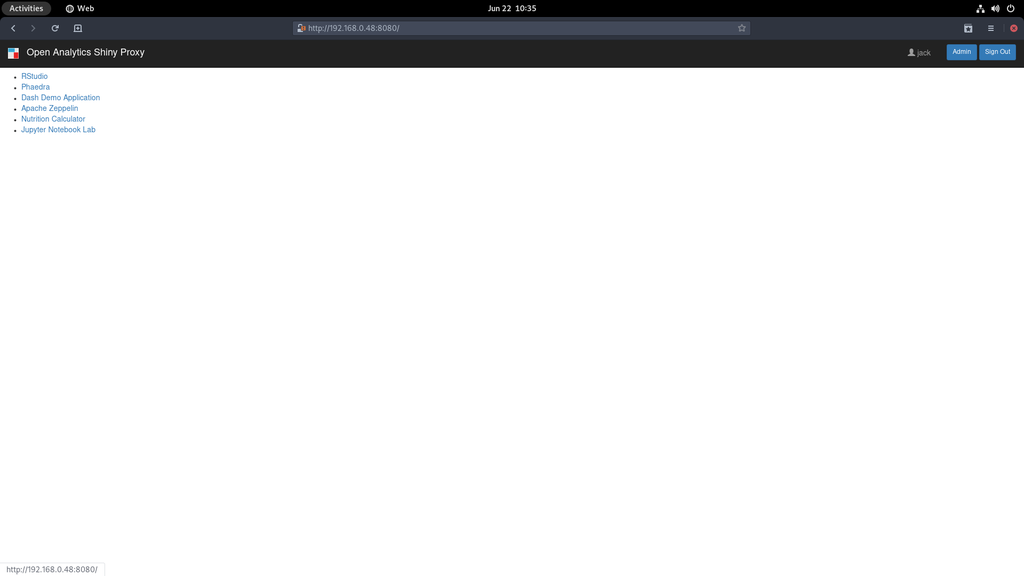

## ShinyProxy

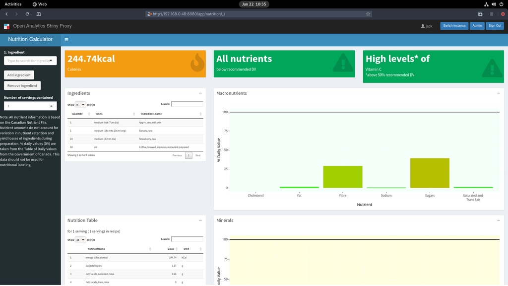

## ShinyProxy Operator

[figure not shown]

## What is Kubernetes?

[figure not shown]

''Kubernetes, also known as K8s, is an open-source system for automating deployment, scaling, and management of containerized applications.'' - https://kubernetes.io/

\(\Rightarrow\) ideal platform for running ShinyProxy

## What is a Kubernetes Operator?

A small piece of software that extends the Kubernetes API in order to fully automate  
the operation of a complex application.

## Why does ShinyProxy need an Operator?

**1) Update configuration of ShinyProxy without affecting the session of a user**

- the Operator manages the lifecycle of ShinyProxy servers
- it creates a new server when the configuration is updated
- it retains the old server as long as users are using it

\(\Rightarrow\) users can keep using their running apps, on the old server

## Why does ShinyProxy need an Operator?

**1) Update configuration of ShinyProxy without affecting the session of a user**

… what if existing users want to start using an app from ShinyProxy B?  
\(\Rightarrow\) users get an update notification and can choose to switch to the new server.

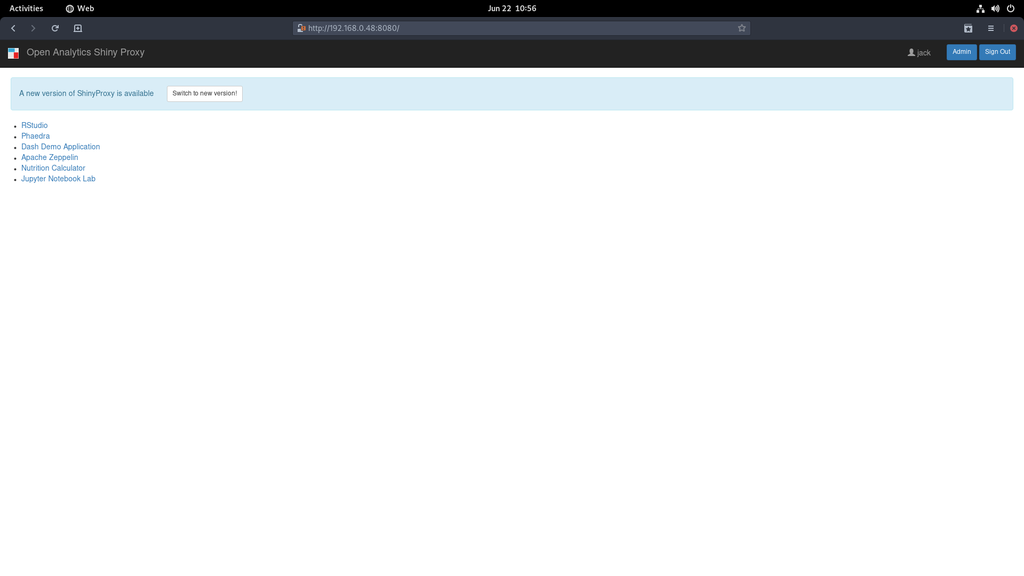

## Why does ShinyProxy need an Operator?

**2) Seamless updates of ShinyProxy server**

## Why does ShinyProxy need an Operator?

**3) Enables multi-tenant hosting of ShinyProxy**

## Why does ShinyProxy need an Operator?

**4) Allows app developers to easily add or update apps**

- users only have to edit the ShinyProxy resource (`CRD`) and apply the resource
- **errors in the configuration do not cause downtime: the operator will never route users to an unreachable instance**

## How?

- ShinyProxy Operator: Kotlin application packaged into a Docker Container
- **Skipper** Ingress controller for routing of users to the correct ShinyProxy server
- **Redis** for session persistence

## Demo time

[figure not shown]

## ShinyProxy as a first class k8s citizen

- `kubernetes-pod-patches` and `kubernetes-additional-manifests`: allows to modify  
  the pods created by ShinyProxy
  - create persistent workspaces for users (e.g. in RStudio, Jupyter notebooks)
  - use custom ServiceAccount for each user and/or app
  - use custom Namespace for each user and/or app
  - \(\Rightarrow\) use your creativity!
- readiness + liveness probes: indicates to Kubernetes when ShinyProxy is ready to accept traffic  
  \(\Rightarrow\) important for Operator (preventing downtime when updating ShinyProxy)

## ShinyProxy Observability

- export Prometheus metrics
- containers contain additional metadata (useful for aggregating logs)

[figure not shown]

## Running multiple instances of an app

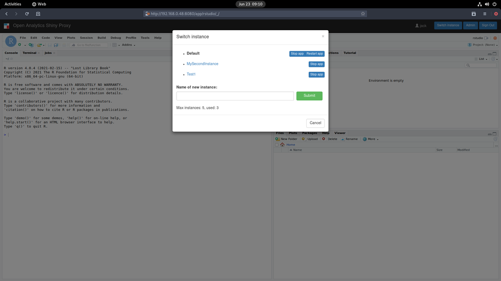

## Reconnecting websockets

[figure not shown]

## App Recovery

[figure not shown]

## Thank you

https://www.openanalytics.eu/contact/

https://shinyproxy.io

https://github.com/openanalytics/shinyproxy